# A.2 Momentum Accelerated Gradient Descent

- In this Section we describe a popular enhancement to the standard gradient descent step, called *momentum accelerated gradient descent*.
- This upgrade to the standard method is designed to ameliorate the *zig-zagging* issue detailed in the previous Section.
- The core of this idea comes from the field of *time series analysis*, and in particular is a tool for smoothing time series known as the *exponential average*.
- You can toggle the code on and off in this presentation via the button below.

```python
from IPython.display import HTML

HTML('''<script>
code_show=true;
function code_toggle() {
 if (code_show){
 $('div.input').hide();
 } else {
 $('div.input').show();
 }
 code_show = !code_show
}
$( document ).ready(code_toggle);
</script>
<form action="javascript:code_toggle()"><input type="submit" value="Click here to toggle on/off the raw code."></form>''')
```

## The exponential average

- In the figure below we show an example of a financial *time series* dataset - a history of the price of a financial stock over 500 periods of time.
- We denote this sequence of $K$ *ordered points* $w^1,\,w^2,\,...,w^K$.
- These points are assumed *ordered*, meaning that the point $w^1$ comes before (that is, it is created and / or collected before) $w^2$, the point $w^2$ before $w^3$, and so on.
- The raw values of a time series often oscillates or *zig-zags* up and down.
- Because of this its common practice to *smooth* a series to remove these zig-zagging motions prior to further analysis.
- The *exponential average* is one of the most popular such smoothing techniques for time series.
- We show the result of smoothing the example time series below via the exponential average - with the resulting exponential average shown as a orange curve.

```python
## This code cell will not be shown in the HTML version of this notebook
from IPython.display import HTML
HTML("""
<video width="1000" height="400" controls loop>
  <source src="videos/animation_9.mp4" type="video/mp4">
  </video>
""")
```

[video not shown]

- Below we animate the same running average process as shown above for the same input series - but for only the first 50 points.

```python
## This code cell will not be shown in the HTML version of this notebook
from IPython.display import HTML
HTML("""
<video width="1000" height="400" controls loop>
  <source src="videos/animation_10.mp4" type="video/mp4">
  </video>
""")
```

[video not shown]

- Before we see how the exponential average is computed lets first see how to compute a *running average*.
- That is the average of the first two points, the average of the first three points, and so forth.
- Naively we could write down this running average as so

\begin{array} \ \text{average of the first $1$ elements:} \,\,\,\,\,\,\,\,\,\,\,\,\, h^1 = w^1 \\ \text{average of the first $2$ elements:} \,\,\,\,\,\,\,\,\,\,\,\,\, h^2 = \frac{w^1 + w^2}{2} \\ \text{average of the first $3$ elements:} \,\,\,\,\,\,\,\,\,\,\,\,\, h^3 = \frac{w^1 + w^2 + w^3}{3} \\ \text{average of the first $4$ elements:} \,\,\,\,\,\,\,\,\,\,\,\,\, h^4 = \frac{w^1 + w^2 + w^3 + w^4}{4} \\ \,\,\,\,\,\,\,\,\,\,\,\,\,\,\,\,\,\,\,\,\,\,\,\,\,\,\,\,\,\,\,\, \vdots \,\,\,\,\,\,\,\,\,\,\,\,\,\,\,\,\,\,\,\,\,\,\,\,\,\,\,\,\,\,\,\,\,\,\,\,\,\,\,\,\,\,\,\,\,\,\,\,\,\,\,\,\,\, \vdots \\ \text{average of the first $k$ elements:} \,\,\,\,\,\,\,\,\,\,\,\,\, h^{k} = \frac{w^1 + w^2 + w^3 + w^4 + \cdots + w^k}{k} \\ \,\,\,\,\,\,\,\,\,\,\,\,\,\,\,\,\,\,\,\,\,\,\,\,\,\,\,\,\,\,\,\, \vdots \,\,\,\,\,\,\,\,\,\,\,\,\,\,\,\,\,\,\,\,\,\,\,\,\,\,\,\,\,\,\,\,\,\,\,\,\,\,\,\,\,\,\,\,\,\,\,\,\,\,\,\,\,\, \vdots \\ \end{array}

- Notice how at each step here the average computation $h^t$ *summarizes* the input points $w^1$ through $w^k$ via a simple summary statistic: their sample mean.
- However as written above, we *need every raw point $w^1$ through $w^k$* in order to compute the running average $h^k$.
- Fortunately we can write this running average more effeciently by studying the form of each computation.
- For example notice how the average of $x^1$ and $x^2$ can be written as

$$ h^2 = \frac{w^1 + w^2}{2} = \frac{h^1 + w^2}{2} = \frac{1}{2}h^1 + \frac{1}{2}w^2. $$

$$ h^3 = \frac{w^1 + w^2 + w^3}{3} = \frac{2\frac{w^1 + w^2}{2} + w^3}{3} = \frac{2h^2 + w^3}{3} = \frac{2}{3}h^2 + \frac{1}{3}w^3. $$

- In general we can express the $k^{th}$ running average $h^{k}$ for $k > 1$ in the same sort of way

$$ h^{k} = \frac{k-1}{k}h^{t-1} + \frac{1}{k}w^k. $$

\begin{equation} h^{k} = \beta \, h^{k-1} + \left(1 - \beta\right)w^k. \end{equation}

- The smaller we set $\beta$ the more our exponential average approximates the raw (zig-zagging) time series itself, while the larger we set it the more each subsequent average looks like its predecessor.
- This idea holds for time series *irregardless of their input dimension* (like the steps of a local optimization run).
- We can likewise define the exponential average of a time series of general $N$ dimensional points $\mathbf{w}^1,\,\mathbf{w}^2,\,...,\mathbf{w}^K$ by initializing $\mathbf{h}^1 = \mathbf{w}^1$ and then for $k > 1$ building $\mathbf{h}^k$ as

$$ \mathbf{h}^{k} = \beta \, \mathbf{h}^{k-1} + \left(1 - \beta\right)\mathbf{w}^k. $$

- Here the exponential average at step $k$ $\mathbf{h}^k$ is also $N$ dimensional.

## Ameliorating the zig-zag behavior of gradient descent

- How can we smooth gradient descent, ameliorating the zig-zag problem discussed in the previous Section?
- We apply exponential average to the descent directions $-\nabla g\left(\mathbf{w}^{0}\right),\,-\nabla g\left(\mathbf{w}^{1}\right),...,-\nabla g\left(\mathbf{w}^{K-1}\right)$, since they create the zig-zagging problem.
- With an initial descent direction $\mathbf{d}^0 = \nabla g\left(\mathbf{w}^0\right)$.
- Then for $k -1 > 0$ the $\left(k-1\right)^{th}$ exponentially averaged descent direction $\mathbf{d}^{k-1}$.

$$ \mathbf{d}^{k-1} = \beta \, \mathbf{d}^{k-2} - \left(1 - \beta\right)\nabla g\left(\mathbf{w}^{k-1}\right) $$

- We can then use this descent direction in our generic local optimization framework to step as

\begin{equation} \mathbf{w}^{\,k} = \mathbf{w}^{\,k-1} + \alpha \, \mathbf{d}^{k-1}. \end{equation}

- Together this adds only a single step to our gradient descent scheme

$$ \mathbf{d}^{k-1} = \beta \, \mathbf{d}^{k-2} - \left(1 - \beta\right)\nabla g\left(\mathbf{w}^{k-1}\right) \\ \mathbf{w}^{\,k} = \mathbf{w}^{\,k-1} + \alpha \, \mathbf{d}^{k-1}. \,\,\,\,\,\,\,\,\,\,\,\,\, \,\,\,\,\,\,\,\,\,\,\,\,\, \,\,\, $$

- This simple adjustment to gradient descent is often called *momentum acclerated gradient descent*.
- The term 'momentum' here refers to the new exponentially averaged descent direction $\mathbf{d}^{k-1}$.
- As with any exponential average the choice of $\beta \in \left[0,1\right]$ provides a trade-off between here.
- The smaller $\beta$ is chosen the *more* the exponential average resembles the actual sequence of negative descent directions.
- The larger $\beta$ is chosen the *less* these exponentially averaged descent steps resemble the negative gradient directions.
- Often in practice larger values of $\beta$ are used, in the range $\left[0.7,1\right]$.

#### Example. Gradient descent directions on the contour plot of a quadratic function

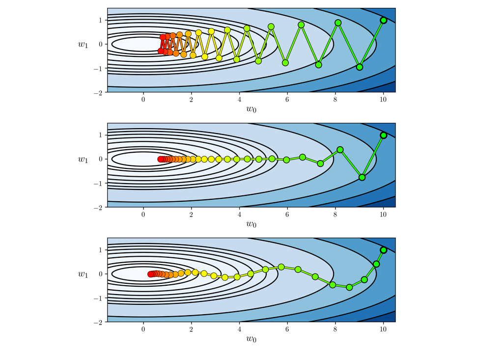

```python
## This code cell will not be shown in the HTML version of this notebook
# define constants for a N=2 input quadratic
a1 = 0
b1 = 0*np.ones((2,1))
C1 = np.array([[0.5,0],[0,9.75]])

# a quadratic function defined using the constants above
g = lambda w: (a1 + np.dot(b1.T,w) + np.dot(np.dot(w.T,C1),w))[0]

w = np.array([10.0,1.0]); max_its = 25; alpha_choice = 10**(-1);
beta = 0
weight_history_1,cost_history_1 = momentum(g,alpha_choice,beta,max_its,w)

beta = 0.1;
weight_history_2,cost_history_2 = momentum(g,alpha_choice,beta,max_its,w)

beta = 0.7
weight_history_3,cost_history_3 = momentum(g,alpha_choice,beta,max_its,w)

# show run in both three-dimensions and just the input space via the contour plot
histories = [weight_history_1,weight_history_2,weight_history_3]
gs = [g,g,g]
static_plotter.two_input_contour_vert_plots(gs,histories,num_contours = 25,xmin = -1.5,xmax = 10.5,ymin = -2.0,ymax = 1.5)
```